# FMT 16S Microbiome Analysis

April Jauhal

2026-04-16

This notebook contains code used for figure analysis in figures 1 and 2. In this workflow, 16S data is processed, alpha and beta diversity and ANCOMBC2 analysis is performed, and data is formatted for RPCA analysis (see RPCA.ipynb). Also contains code used to generate Figure 1, as well as example code for the generation of figure 2 (final Figure 2 subfigures were generated in PRISM).

## Data Processing

Set Directory

```r
FMT_dir = "C:/Users/ETTINA03/NYU Langone Health Dropbox/April Jauhal/Shenhav_Lab/Morrowitz_16S/2024_Jul_FMT/"
FMT_figpath = paste0(FMT_dir, "/Figures/")
FMT_RPCA_path = paste0(FMT_dir, "/RPCA_3/")
```

Loading libraries

```r
library(dplyr)
library(phyloseq)
library(readxl)
library(stringr)
library(vegan)
```

```r
library(ggplot2)
library(ggpubr)
library(ANCOMBC)
library(ggprism)
```

Defining colors for plots to align with prism color scheme

```r
five_colors <- c(
  "FMT-ABX" = "#AD07E3",
  "FMT-HD" = "#FF8000",
  "PBS" = "#00C000",
  "Untreated" = "#0000FF",
  "ABX (2W)" = "#FF0000")

three_colors <- c(
  "FMT-ABX" = "#FF0000",
  "FMT-HD" = "#00C000",
  "PBS" = "#0000FF"
)

four_colors <- c(
  "FMT-ABX" = "#AD07E3",
  "FMT-HD" = "#FF8000",
  "PBS" = "#00C000",
  "Untreated" = "#0000FF")
```

Loading 16S dataset and converting to physeq objects

```r
theme_set(theme_bw())

# Create figure path if it doesn't already exist
if (!dir.exists(FMT_figpath)) {
  dir.create(FMT_figpath, recursive = TRUE)
}

count_table = read_xlsx(paste0(FMT_dir, "FMT_July2024_16S_Sequencing_Stats.xlsx"),
                        sheet="Microbial Composition") %>%
  dplyr::rename(taxonomy=`Amplicon Sequencing Variant (ASV)`)
sample_info = read_xlsx(paste0(FMT_dir, "FMT_July2024_16S_Sequencing_Stats.xlsx"),
                        sheet="Metadata") %>%
  as.data.frame() %>% mutate(Cage = paste0(Label, "_", Cage)) %>%
  mutate(Treatment = case_when(Label == "ABX" ~ "ABX (2W)",
                               Label == "Donor" ~ "Donor",
                               Label == "FMTABX" ~ "FMT-ABX",
                               Label == "FMTCTRL" ~ "FMT-HD",
                               Label == "FMTPBS" ~ "PBS",
                               Label == "Naive" ~ "Untreated",
                               TRUE ~ NA,
                               ))


bridge_otu_df = count_table %>% dplyr::select(`taxonomy`)
bridge_otu_df$ID = paste0("otu_", 1:nrow(bridge_otu_df))


tax_df <- data.frame(str_split(count_table$taxonomy, ';')) %>% t() %>% data.frame
colnames(tax_df) <- c("Domain", "Phylum",  "Class",  "Order",  "Family",  "Genus", "Species")
tax_df <- tax_df %>% dplyr::mutate(taxonomy = apply(., 1, function(row) paste(row, collapse = ";"))) %>% left_join(bridge_otu_df) %>% dplyr::select(-taxonomy) %>% tibble::column_to_rownames('ID')
tax_df[] <- lapply(lapply(tax_df, function(x) sub("[a-z]__", "", x)), function(x) sub("^__$", "Unknown", x))

new_taxa_table = tax_df %>% slice(0)
for (each_genus in unique(tax_df$Genus)) {
  subset_df = tax_df %>% filter(Genus==each_genus)
  if (each_genus %in% c("uncultured", "Unknown")) {
    subset_df = subset_df %>% mutate(Genus = paste0(Genus, "_", row_number()))
  }
  new_taxa_table = rbind(new_taxa_table, subset_df)
}


otu_df = count_table %>% left_join(bridge_otu_df) %>% select(-taxonomy) %>% tibble::column_to_rownames('ID')
rownames(sample_info) <- sample_info$Sample

# Version for original relative abundance
FMT_physeq_rel = phyloseq(otu_table(otu_df, taxa_are_rows=TRUE), tax_table(as.matrix(new_taxa_table)), sample_data(sample_info))

seq_stats = read_xlsx(paste0(FMT_dir, "FMT_July2024_16S_Sequencing_Stats.xlsx"),
                      sheet="Sequencing Statistics")
count_data = otu_df
for (sampleid in seq_stats$`Sample Name`) {
  num_reads = seq_stats %>% filter(`Sample Name`==sampleid) %>% pull(`Total Read Pairs`)
  count_data[sampleid] <- round(count_table[sampleid]*num_reads, digits = 0)
}

# Version for whole counts
FMT_physeq_counts = phyloseq(otu_table(as.matrix(count_data), taxa_are_rows=TRUE), tax_table(as.matrix(new_taxa_table)), sample_data(sample_info))
```

Filtering out mitochondria and choloroplast DNA and calculating relative abundance

```r
# Version for relative abundance without mitochondria/chloroplasts
FMT_physeq_filtered_rel = transform_sample_counts(subset_taxa(FMT_physeq_rel, !Genus %in% c("Mitochondria", "Chloroplast")), function(x) x / sum(x))

# Version for whole counts without michrondria/chloroplasts
FMT_physeq_filtered_counts = subset_taxa(FMT_physeq_counts, !Genus %in% c("Mitochondria", "Chloroplast"))
```

# Constructing relative abundance barplots (class)

barplots are shown in Figure 1B

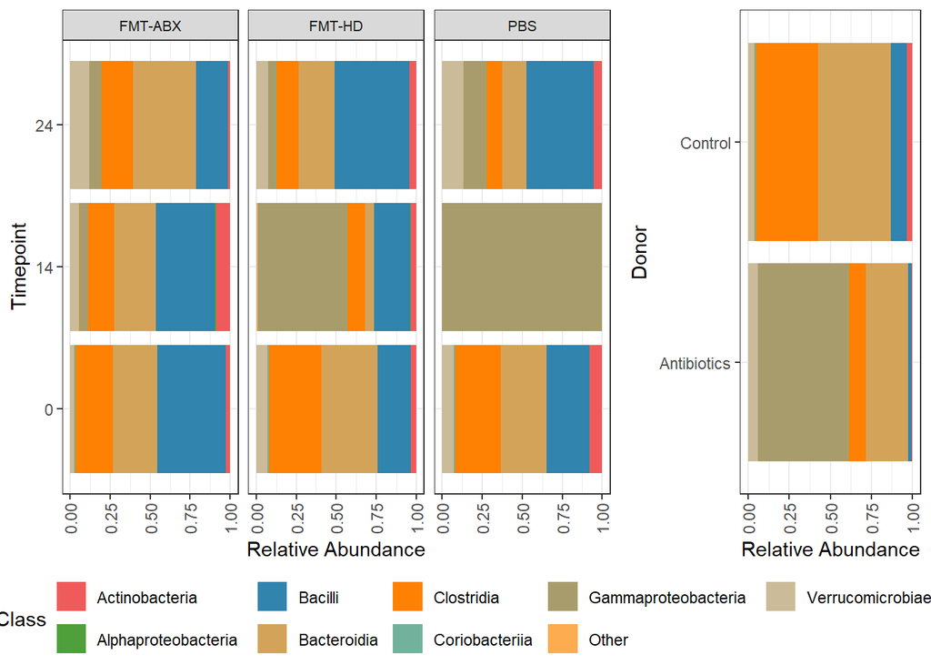

```r
library(RColorBrewer)
set.seed(2)
palette <- colorRampPalette(brewer.pal(12, "Paired"))(50)
palette_scrambled <- sample(palette, 50)

# class-level plotting data
plot_data_class0 = FMT_physeq_filtered_rel %>%
  tax_glom(taxrank = "Class") %>%
  psmelt() %>% group_by(Class, Sample) %>% dplyr::summarize(class_count = sum(Abundance)) %>% left_join(sample_data(FMT_physeq_filtered_rel))
class_1perc = plot_data_class0 %>% group_by(Class) %>%
  dplyr::summarize(max = max(class_count)) %>%
  filter(max >= 0.01) %>% pull(Class)
plot_data_class = plot_data_class0 %>% mutate(Class = ifelse(Class %in% class_1perc, Class, "Other"))


collapse_class <- function(label, timepoint) {
  df = plot_data_class %>%
      filter(Label==label, Timepoint==timepoint) %>%
            group_by(Label, Class) %>%
      dplyr::summarize(x=sum(class_count), Timepoint=timepoint, Label=label) %>%
        unique()
  return(df %>% mutate(class_count = x/sum(df$x, na.rm = TRUE)))
}
grouped_plot_data_class <- do.call(rbind,
        list(collapse_class("FMTPBS", 0),
             collapse_class("FMTPBS", 14),
             collapse_class("FMTPBS", 24),
             collapse_class("FMTCTRL", 0),
             collapse_class("FMTCTRL", 14),
             collapse_class("FMTCTRL", 24),
             collapse_class("FMTABX", 0),
             collapse_class("FMTABX", 14),
             collapse_class("FMTABX", 24)))
rel_barplot_class = ggarrange(
  ggplot(grouped_plot_data_class %>%
           mutate(Label = ifelse(Label=="FMTABX", "FMT-ABX",
                                 ifelse(Label=="FMTPBS", "PBS",
                                        ifelse(Label=="FMTCTRL", "FMT-HD", NA)))), aes(y=as.factor(Timepoint), x=class_count, fill=Class)) + geom_bar(stat="identity") +
  theme(axis.text.x = element_text(angle = 90, vjust = 0.5, hjust = 1),
        legend.position = "bottom",
        strip.text.y= element_text(size=8),
        strip.text.x= element_text(size=8)) +
  facet_grid(.~Label) +
  scale_fill_manual(values = palette_scrambled) + scale_color_manual(values = palette_scrambled) + ylab("Timepoint") + xlab("Relative Abundance"),
  ggplot(plot_data_class %>% filter(!is.na(FMT_Donor)) %>%
           mutate(Subject = ifelse(Subject=="Donor_Abx", "Antibiotics",
                                 ifelse(Subject=="Donor_CTRL", "Control", NA))), aes(y=as.factor(Subject), x=class_count, fill=Class)) + geom_bar(stat="identity") +
  theme(axis.text.x = element_text(angle = 90, vjust = 0.5, hjust = 1),
        strip.text.y= element_text(size=8),
        strip.text.x= element_text(size=8)) +
  scale_fill_manual(values = palette_scrambled) + scale_color_manual(values = palette_scrambled) + ylab("Donor") + xlab("Relative Abundance"),
  common.legend = TRUE, widths = c(2,1), legend = "bottom")
rel_barplot_class
```

```r
ggexport(rel_barplot_class, dpi = 600, width = 700, height=200, filename = paste0(FMT_figpath, "rel_barplot_class.png"))
```

```
## [1] "C:/Users/ETTINA03/NYU Langone Health Dropbox/April Jauhal/Shenhav_Lab/Morrowitz_16S/2024_Jul_FMT//Figures/rel_barplot_class%03d.png"
```

```
## file saved to C:/Users/ETTINA03/NYU Langone Health Dropbox/April Jauhal/Shenhav_Lab/Morrowitz_16S/2024_Jul_FMT//Figures/rel_barplot_class%03d.png
```

## Alpha Diversity analysis

Alpha diversity analysis was initially performed by SeqCenter, results are parsed here and used to generate sublots for Figure 1FG.

```r
Alpha_df = read_xlsx(paste0(FMT_dir, "FMT_July2024_16S_Sequencing_Stats.xlsx"),
                     sheet="Alpha Diversity Metrics")
div_sample_data = sample_data(FMT_physeq_filtered_rel) %>% data.frame() %>% left_join(Alpha_df)
```

```r
rownames(div_sample_data) <- div_sample_data$Sample
sample_data(FMT_physeq_filtered_rel) <- sample_data(div_sample_data)

rich_plot = ggplot(div_sample_data %>% filter(!is.na(Timepoint), Timepoint==24) %>%
                     mutate(TP_label = ifelse(Timepoint==24, "Day 24", NA)),
                   aes(x=Treatment, y=`Observed Features`, color=Treatment)) +
    geom_boxplot(show.legend = FALSE) + geom_jitter(width = 0.2, height = 0, size = 1) +
    facet_grid(.~TP_label) +
    theme(axis.text.x = element_text(angle = 45, hjust = 1)) +
    theme(legend.position = "left") +
    geom_point() + theme(legend.position = "none") +
    stat_compare_means(comparisons = list(c("FMT-HD", "Untreated"),
                                          c("PBS", "Untreated"),
                                          c("FMT-ABX", "Untreated")), label = "p.signif",
                       bracket.size = 0.75, tip.length = 0)

faith_plot = ggplot(div_sample_data %>% filter(!is.na(Timepoint), Timepoint==24) %>%
                     mutate(TP_label = ifelse(Timepoint==24, "Day 24", NA)),
                    aes(x=Treatment, y=`Faith's Phylogenetic Diversity`, color=Treatment)) +
    geom_boxplot(show.legend = FALSE) + geom_jitter(width = 0.2, height = 0, size = 1) +
    facet_grid(.~TP_label) +
    theme(axis.text.x = element_text(angle = 45, hjust = 1)) +
    theme(legend.position = "left") +
    geom_point() + theme(legend.position = "none") +
    stat_compare_means(comparisons = list(c("FMT-HD", "Untreated"),
                                          c("PBS", "Untreated"),
                                          c("FMT-ABX", "Untreated")), label = "p.signif",
                       bracket.size = 0.75, tip.length = 0)

rich_prism_plot = rich_plot + theme_prism(base_size = 12) +
  scale_color_manual(values = four_colors) +
  theme(axis.text.x = element_text(angle = 45, hjust = 1, vjust = 1))

faith_prism_plot = faith_plot + theme_prism(base_size = 12) +
  scale_color_manual(values = four_colors) +
  theme(axis.text.x = element_text(angle = 45, hjust = 1, vjust = 1))

alpha_div_plot = ggarrange(rich_prism_plot, faith_prism_plot, nrow = 1)

ggexport(alpha_div_plot,
         dpi = 300, width = 600, height = 400, filename = paste0(FMT_figpath, "diversity.png"))
```

```
## [1] "C:/Users/ETTINA03/NYU Langone Health Dropbox/April Jauhal/Shenhav_Lab/Morrowitz_16S/2024_Jul_FMT//Figures/diversity%03d.png"
```

```
## file saved to C:/Users/ETTINA03/NYU Langone Health Dropbox/April Jauhal/Shenhav_Lab/Morrowitz_16S/2024_Jul_FMT//Figures/diversity%03d.png
```

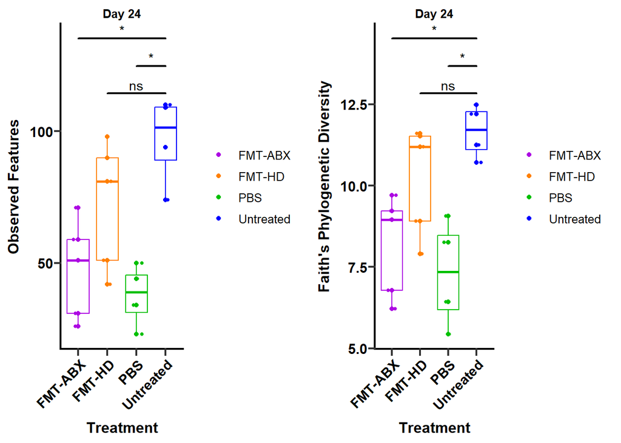

```r
alpha_div_plot
```

## Beta diversity analysis

Beta diversity calculations were performed on filtered relative abundance data

```r
meta = data.frame(sample_data(FMT_physeq_filtered_rel)) %>%
  mutate(Treatment = case_when(Label == "ABX" ~ "ABX (2W)",
                               Label == "Donor" ~ "Donor",
                               Label == "FMTABX" ~ "FMT-ABX",
                               Label == "FMTCTRL" ~ "FMT-HD",
                               Label == "FMTPBS" ~ "PBS",
                               Label == "Naive" ~ "Untreated",
                               TRUE ~ NA,
                               ))
otu = t(otu_table(FMT_physeq_filtered_rel))
jsd_res <- distance(t(otu_table(FMT_physeq_filtered_rel)), method='jsd')

jaccard = distance(otu, method='jaccard')

FMT_genus <- tax_glom(FMT_physeq_filtered_rel, taxrank = "Genus", NArm = TRUE)
otu_genus = t(otu_table(FMT_genus))
jaccard_genus = distance(otu_genus, method='jaccard')

FMT_family <- tax_glom(FMT_physeq_filtered_rel, taxrank = "Family", NArm = TRUE)
otu_family = t(otu_table(FMT_family))
jaccard_family = distance(otu_family, method='jaccard')
```

```r
jaccard_FMT_dur_df = data.frame(Label=character(), Comparison=logical(), TP_Comparison=logical(), Jaccard=numeric())

Sample_list5 = list(meta %>% filter(Label=="FMTCTRL", Timepoint %in% c(24, 14, 0)) %>% pull(Sample),
                    meta %>% filter(Label=="FMTABX", Timepoint %in% c(24, 14, 0 )) %>% pull(Sample),
                    meta %>% filter(Label=="FMTPBS", Timepoint %in% c(24, 14, 0 )) %>% pull(Sample))
for (Samples in Sample_list5) {
  for(each_sample in Samples) {

    Sample_Label = meta %>% filter(Sample==each_sample) %>% pull(Treatment)
    Sample_Time = meta %>% filter(Sample==each_sample) %>% pull(Timepoint)

    for (compare_sample in unlist(Sample_list5[Sample_list5!=each_sample])) {
      Compare_Sample_Label = meta %>% filter(Sample==compare_sample) %>% pull(Treatment)
      Compare_Sample_Time = meta %>% filter(Sample==compare_sample) %>% pull(Timepoint)

      each_df = data.frame(Treatment=Sample_Label,
                           Comparison = ifelse(Sample_Label==Compare_Sample_Label, 'Self', 'Other'),
                           TP_Comparison =  case_when(Sample_Time == 24 & Compare_Sample_Time == 24  ~ "24 vs. 24 Days",
                                                      Sample_Time == 24 & Compare_Sample_Time == 14 ~ "24 vs. 14 Days",
                                                      Sample_Time == 14 & Compare_Sample_Time == 24 ~ "14 vs. 24 Days",
                                                      Sample_Time == 14 & Compare_Sample_Time == 14 ~ "14 vs. 14 Days",
                                                      Sample_Time == 0 & Compare_Sample_Time == 0 ~ "0 vs. 0 Days",
                                                      Sample_Time == 0 & Compare_Sample_Time == 14 ~ "0 vs. 14 Days",
                                                      Sample_Time == 14 & Compare_Sample_Time == 0 ~ "14 vs. 0 Days",
                                                      Sample_Time == 0 & Compare_Sample_Time == 24 ~ "0 vs. 24 Days",
                                                      Sample_Time == 24 & Compare_Sample_Time == 0 ~ "24 vs. 0 Days",
                                                      TRUE ~ "Other"),
                           Jaccard=as.matrix(jaccard)[each_sample, compare_sample])
      jaccard_FMT_dur_df = rbind(jaccard_FMT_dur_df, each_df)
    }
  }
}
```

Building subplots for figure 1CDE

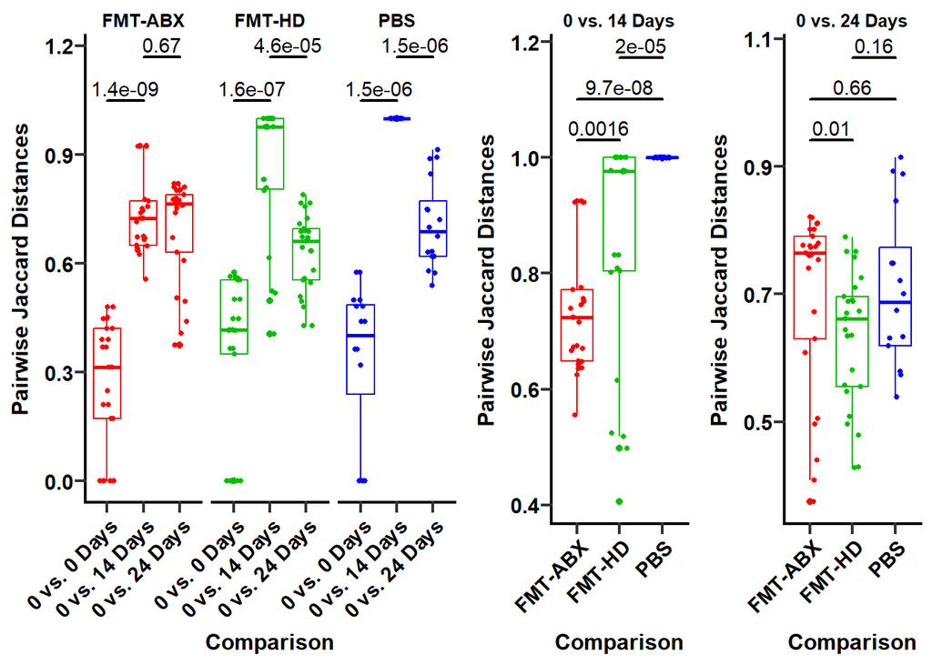

```r
jaccard_FMPT_dur_subplot1 = jaccard_FMT_dur_df %>% filter(Comparison=="Self", TP_Comparison %in% c('0 vs. 0 Days', '0 vs. 14 Days', '0 vs. 24 Days')) %>% ggplot(aes(x=TP_Comparison, y=Jaccard, color = Treatment)) + geom_boxplot() +
  geom_jitter(width = 0.2, height = 0, size = 1) + xlab("Comparison") + ylab("Pairwise Jaccard Distances") +
    theme(axis.text.x = element_text(angle = 45, hjust = 1)) +
    stat_compare_means(comparisons = list(c("0 vs. 0 Days", "0 vs. 14 Days"),
                                          c("0 vs. 14 Days", "0 vs. 24 Days")),
                       bracket.size = 0.75, tip.length = 0) + facet_grid(.~Treatment)

jaccard_FMPT_dur_subplot2 =   jaccard_FMT_dur_df %>% filter(Comparison=="Self", TP_Comparison %in% c('0 vs. 14 Days')) %>% ggplot(aes(x=Treatment, y=Jaccard, color = Treatment)) + geom_boxplot() + geom_jitter(width = 0.2, height = 0, size = 1) +
  xlab("Comparison") + ylab("Pairwise Jaccard Distances") + theme(axis.text.x = element_text(angle = 45, hjust = 1)) +
    stat_compare_means(comparisons = list(c("FMT-ABX", "FMT-HD"),
                                          c("FMT-ABX", "PBS"),
                                          c("PBS", "FMT-HD")),
                       bracket.size = 0.75, tip.length = 0) + facet_grid(.~TP_Comparison)
jaccard_FMPT_dur_subplot3 =     jaccard_FMT_dur_df %>% filter(Comparison=="Self", TP_Comparison %in% c('0 vs. 24 Days')) %>% ggplot(aes(x=Treatment, y=Jaccard, color = Treatment)) + geom_boxplot() + geom_jitter(width = 0.2, height = 0, size = 1) +
  xlab("Comparison") + ylab("Pairwise Jaccard Distances") + theme(axis.text.x = element_text(angle = 45, hjust = 1)) +
    stat_compare_means(comparisons = list(c("FMT-ABX", "FMT-HD"),
                                          c("FMT-ABX", "PBS"),
                                          c("PBS", "FMT-HD")),
                       bracket.size = 0.75, tip.length = 0) + facet_grid(.~TP_Comparison)

jaccard_FMPT_dur_subprism1 = jaccard_FMPT_dur_subplot1 + theme_prism(base_size = 12) +
  scale_color_manual(values = three_colors) + theme(legend.position="none",
                                                    axis.text.x = element_text(angle = 45, hjust = 1, vjust = 1))
jaccard_FMPT_dur_subprism2 = jaccard_FMPT_dur_subplot2 + theme_prism(base_size = 12) +
  scale_color_manual(values = three_colors) + theme(legend.position="none",
                                                    axis.text.x = element_text(angle = 45, hjust = 1, vjust = 1))
jaccard_FMPT_dur_subprism3 = jaccard_FMPT_dur_subplot3 + theme_prism(base_size = 12) +
  scale_color_manual(values = three_colors) + theme(legend.position="none",
                                                    axis.text.x = element_text(angle = 45, hjust = 1, vjust = 1))

jaccard_FMT_dur_plot_prism = ggarrange(jaccard_FMPT_dur_subprism1, jaccard_FMPT_dur_subprism2, jaccard_FMPT_dur_subprism3, nrow = 1, widths = c(2,1, 1))
jaccard_FMT_dur_plot_prism
```

```r
ggexport(jaccard_FMT_dur_plot_prism,
         dpi = 300, width = 600, height = 400, filename = paste0(FMT_figpath, "Treatment_effect.png"))
```

```
## [1] "C:/Users/ETTINA03/NYU Langone Health Dropbox/April Jauhal/Shenhav_Lab/Morrowitz_16S/2024_Jul_FMT//Figures/Treatment_effect%03d.png"
```

```
## file saved to C:/Users/ETTINA03/NYU Langone Health Dropbox/April Jauhal/Shenhav_Lab/Morrowitz_16S/2024_Jul_FMT//Figures/Treatment_effect%03d.png
```

Comparing day 24 samples to their donors for supplementary figure 1

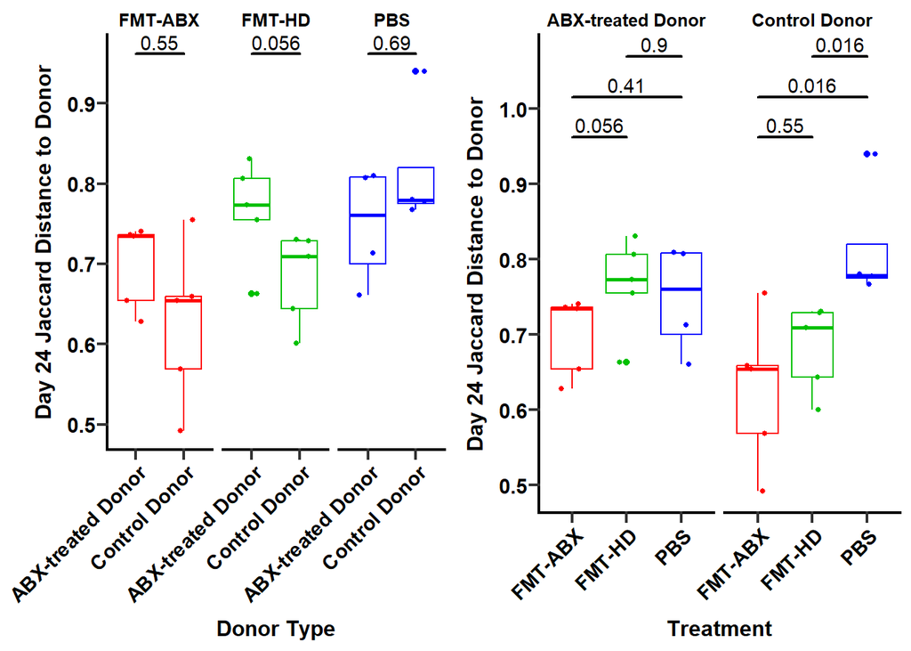

```r
jaccard_donor_df = data.frame(Label=character(), Cagemate=logical(), Jaccard=numeric())

Sample_list2 = list(meta %>% filter(Label=="FMTCTRL", Timepoint==24) %>% pull(Sample),
                    meta %>% filter(Label=="FMTABX", Timepoint==24) %>% pull(Sample),
                    meta %>% filter(Label=="FMTPBS", Timepoint==24) %>% pull(Sample))
for (Samples in Sample_list2) {
  for(each_sample in Samples) {

    Sample_Label = meta %>% filter(Sample==each_sample) %>% pull(Treatment)

    for (compare_sample in meta %>% filter(!is.na(FMT_Donor)) %>% pull(Sample)) {
      Donor_type = meta %>% filter(Sample==compare_sample) %>% pull(FMT_Donor)
      each_df = data.frame(Treatment=Sample_Label,
                           Donor_type = Donor_type,
                           Jaccard=as.matrix(jaccard)[each_sample, compare_sample])
      jaccard_donor_df = rbind(jaccard_donor_df, each_df)
    }
  }
}

jaccard_donor_plot = jaccard_donor_df %>%
  mutate(Donor_label = case_when(Donor_type=="Donor_ABX" ~ "ABX-treated Donor",
                                 Donor_type=="Donor_CTRL" ~ "Control Donor",
                                 TRUE ~ NA)) %>%
  ggplot(aes(x=Donor_label, y=Jaccard, color = Treatment)) + geom_boxplot() + geom_jitter(width = 0.2, height = 0, size = 1) +
  ylab("\nDay 24 Jaccard Distance to Donor") + xlab("Donor Type") +
  theme(axis.text.x = element_text(angle = 45, hjust = 1),
        legend.position = 'none') +
  stat_compare_means(comparisons = list(c("ABX-treated Donor", "Control Donor")),
                     bracket.size = 0.75, tip.length = 0) + facet_grid(.~Treatment)

jaccard_donor_plot2 = jaccard_donor_df %>%
  mutate(Donor_label = case_when(Donor_type=="Donor_ABX" ~ "ABX-treated Donor",
                                 Donor_type=="Donor_CTRL" ~ "Control Donor",
                                 TRUE ~ NA)) %>%
  ggplot(aes(x=Treatment, y=Jaccard, color = Treatment)) + geom_boxplot() + geom_jitter(width = 0.2, height = 0, size = 1) +
  ylab("Day 24 Jaccard Distance to Donor") + xlab("Treatment") +
  theme(axis.text.x = element_text(angle = 45, hjust = 1),
        legend.position = 'none') +
  stat_compare_means(comparisons = list(c("FMT-ABX", "FMT-HD"),
                                          c("FMT-ABX", "PBS"),
                                          c("PBS", "FMT-HD")),
                     bracket.size = 0.75, tip.length = 0) + facet_grid(.~Donor_label)

jaccard_donor_prism_plot =jaccard_donor_plot + theme_prism(base_size = 12) +
  scale_color_manual(values = three_colors) +
  theme(axis.text.x = element_text(angle = 45, hjust = 1, vjust = 1),
        legend.position = 'none')

jaccard_donor_prism_plot2 = jaccard_donor_plot2 + theme_prism(base_size = 12) +
  scale_color_manual(values = three_colors) +
  theme(axis.text.x = element_text(angle = 45, hjust = 1, vjust = 1),
        legend.position = 'none')

ggarrange(jaccard_donor_prism_plot, jaccard_donor_prism_plot2)
```

```r
ggexport(ggarrange(jaccard_donor_prism_plot, jaccard_donor_prism_plot2),
         dpi = 300, width = 500, height = 400, filename = paste0(FMT_figpath, "Donor_comparison.png"))
```

```
## [1] "C:/Users/ETTINA03/NYU Langone Health Dropbox/April Jauhal/Shenhav_Lab/Morrowitz_16S/2024_Jul_FMT//Figures/Donor_comparison%03d.png"
```

```
## file saved to C:/Users/ETTINA03/NYU Langone Health Dropbox/April Jauhal/Shenhav_Lab/Morrowitz_16S/2024_Jul_FMT//Figures/Donor_comparison%03d.png
```

## Data processing for RPCA analysis

Loaded physeq data is processed for analysis via FMT_RPCA.ipynb

```r
FMT_physeq_nodonor_24 <- subset_samples(subset_samples(FMT_physeq_filtered_counts %>% tax_glom(taxrank = "Genus"), Label %in% c("FMTABX", "FMTCTRL", "FMTPBS")),
                                        Timepoint==24)
sample_metadata_rpca <- data.frame(sample_data(FMT_physeq_nodonor_24)) %>% rename(sampleid=Sample) %>% select(sampleid, everything())
subject_metadata_rpca <- sample_metadata_rpca %>% select(Subject, Label) %>% unique()

# Uncomment to prepare files for CTF
library(biomformat)
FMT_physeq.biom <- make_biom(otu_table(FMT_physeq_nodonor_24))
#write_biom(FMT_physeq.biom, biom_file="paste0(FMT_RPCA_path, "/16S_forRPCA.biom")
# write.table(sample_metadata_rpca, file=paste0(FMT_RPCA_path, "RPCA_sample_metadata.tsv",
#             quote=FALSE, sep='\t', row.names = FALSE)
# write.table(subject_metadata_rpca, file=paste0(FMT_dir, "RPCA_subject_metadata.tsv",
#             quote=FALSE, sep='\t', row.names = FALSE)
```

Loaded results following RPCA analysis via FMT_RPCA.ipynb

```r
ord_text = readLines(paste0(FMT_RPCA_path, "/16S_RPCA/biplot_unzipped/629da861-81c6-48df-a17a-8f24eeca9919/data/ordination.txt"))

feat_ord = read.table(textConnection(ord_text[str_detect(ord_text, "otu")]), header = FALSE, col.names = c("Feature", "PC1", "PC2", "PC3")) %>%
  left_join(tax_table(FMT_physeq_nodonor_24) %>%
              as.data.frame() %>% tibble::rownames_to_column("Feature"))
otu_filt_counts = FMT_physeq_filtered_counts %>% otu_table %>% as.data.frame()
tax_filt = FMT_physeq_filtered_counts %>% tax_table %>% as.data.frame()
perc_10 = round(nrow(feat_ord)/10)

PC1_full_num = otu_filt_counts[feat_ord %>% filter(PC1<0) %>% pull(Feature),] %>% colSums()
PC1_full_denom = otu_filt_counts[feat_ord %>% filter(PC1>=0) %>% pull(Feature),] %>% colSums()
PC2_full_num = otu_filt_counts[feat_ord %>% filter(PC2<0) %>% pull(Feature),] %>% colSums()
PC2_full_denom = otu_filt_counts[feat_ord %>% filter(PC2>=0) %>% pull(Feature),] %>% colSums()
PC3_full_num = otu_filt_counts[feat_ord %>% filter(PC3<0) %>% pull(Feature),] %>% colSums()
PC3_full_denom = otu_filt_counts[feat_ord %>% filter(PC3>=0) %>% pull(Feature),] %>% colSums()


PC1_10perc_num = otu_filt_counts[feat_ord %>% arrange(desc(PC1)) %>% slice(1:perc_10) %>% pull(Feature),] %>% colSums()
PC1_10perc_denom = otu_filt_counts[feat_ord %>% arrange(PC1) %>% slice(1:perc_10) %>% pull(Feature),] %>% colSums()
PC2_10perc_num = otu_filt_counts[feat_ord %>% arrange(desc(PC2)) %>% slice(1:perc_10) %>% pull(Feature),] %>% colSums()
PC2_10perc_denom = otu_filt_counts[feat_ord %>% arrange(PC2) %>% slice(1:perc_10) %>% pull(Feature),] %>% colSums()
PC3_10perc_num = otu_filt_counts[feat_ord %>% arrange(desc(PC3)) %>% slice(1:perc_10) %>% pull(Feature),] %>% colSums()
PC3_10perc_denom = otu_filt_counts[feat_ord %>% arrange(PC3) %>% slice(1:perc_10) %>% pull(Feature),] %>% colSums()


PC1_full = log(PC1_full_num/PC1_full_denom) %>% data.frame(PC1_full=.) %>% tibble::rownames_to_column("sampleid")
PC2_full = log(PC2_full_num/PC2_full_denom) %>% data.frame(PC2_full=.) %>% tibble::rownames_to_column("sampleid")
PC3_full = log(PC3_full_num/PC3_full_denom) %>% data.frame(PC3_full=.) %>% tibble::rownames_to_column("sampleid")
PC1_10perc = log(PC1_10perc_num/PC1_10perc_denom) %>% data.frame(PC1_10perc=.) %>% tibble::rownames_to_column("sampleid")
PC2_10perc = log(PC2_10perc_num/PC2_10perc_denom) %>% data.frame(PC2_10perc=.) %>% tibble::rownames_to_column("sampleid")
PC3_10perc = log(PC3_10perc_num/PC3_10perc_denom) %>% data.frame(PC3_10perc=.) %>% tibble::rownames_to_column("sampleid")

log_ratio_df = full_join(full_join(full_join(full_join(full_join(PC1_full, PC2_full),
                                                       PC3_full),
                                             PC1_10perc),
                                   PC2_10perc),
                         PC3_10perc)
subj_ord = read.table(textConnection(ord_text[str_detect(ord_text, "FMT")]), header = FALSE, col.names = c("sampleid", "PC1", "PC2", "PC3")) %>% left_join(log_ratio_df) %>% left_join(sample_metadata_rpca)
PC2_denom_df = tax_filt[feat_ord %>% arrange((PC2)) %>% slice(1:perc_10) %>% pull(Feature),] %>% dplyr::select(Class, Genus)
PC2_num_df = tax_filt[feat_ord %>% arrange(desc(PC2)) %>% slice(1:perc_10) %>% pull(Feature),] %>% dplyr::select(Class, Genus)
PC3_denom_df = tax_filt[feat_ord %>% arrange((PC3)) %>% slice(1:perc_10) %>% pull(Feature),] %>% dplyr::select(Class, Genus)
PC3_num_df = tax_filt[feat_ord %>% arrange(desc(PC3)) %>% slice(1:perc_10) %>% pull(Feature),] %>% dplyr::select(Class, Genus)

bind_rows(
  feat_ord %>% arrange(desc(PC2)) %>% slice(1:perc_10) %>% mutate(Ranking = paste0("Numerator: ", 1:8)) %>%
    dplyr::select(Ranking, PC2, Class, Genus),
  feat_ord %>% arrange((PC2)) %>% slice(1:perc_10) %>% mutate(Ranking = paste0("Denominator: ", 1:8)) %>%
    dplyr::select(Ranking, PC2, Class, Genus)) %>% write.csv(paste0(FMT_dir, "Table1.csv"))
```

## Displaying RPCA results (Note that the final figure was generated in PRISM)

Figure 2A

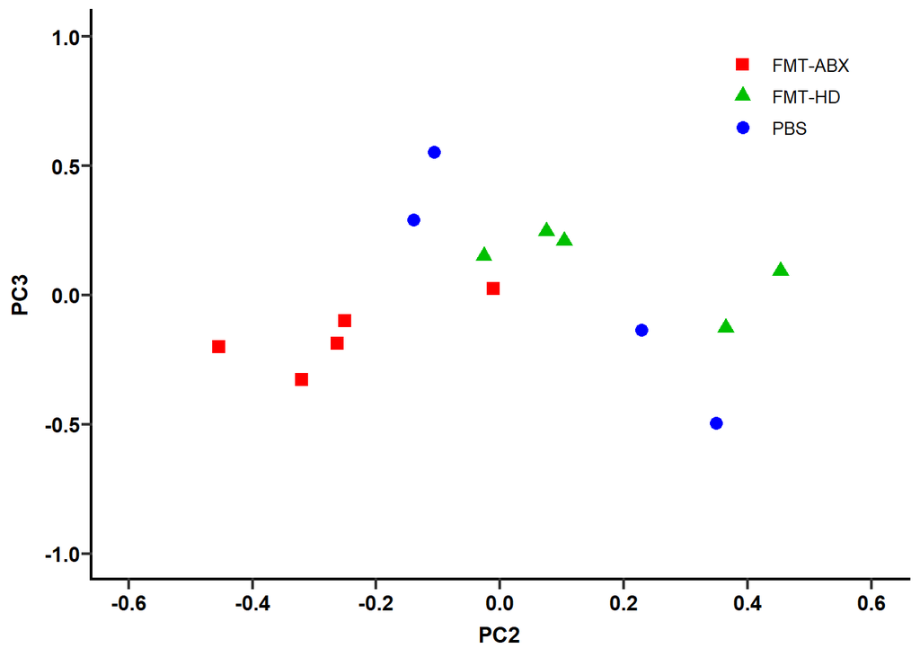

```r
Figure2A = ggplot(subj_ord, aes(x = PC2, y = PC3, shape = Label, color = Label)) +
  geom_point(size = 3) +
  scale_color_manual(
    values = c("FMTABX" = three_colors[["FMT-ABX"]], "FMTCTRL" = three_colors[["FMT-HD"]], "FMTPBS" = three_colors[["PBS"]]),
    labels = c("FMTABX" = "FMT-ABX", "FMTCTRL" = "FMT-HD", "FMTPBS" = "PBS")
  ) +
  scale_shape_manual(
    values = c("FMTABX" = 15, "FMTCTRL" = 17, "FMTPBS" = 16),  # square, triangle, circle
    labels = c("FMTABX" = "FMT-ABX", "FMTCTRL" = "FMT-HD", "FMTPBS" = "PBS")
  ) +
  scale_x_continuous(
    limits = c(-0.6, 0.6),
    breaks = seq(-0.6, 0.6, by = 0.2),
    labels = scales::number_format(accuracy = 0.1)
  ) +
  scale_y_continuous(
    limits = c(-1.0, 1.0),
    breaks = seq(-1.0, 1.0, by = 0.5)
  ) +
  labs(
    x = "PC2",
    y = "PC3",
    color = NULL,
    shape = NULL
  ) +
  theme_prism(base_size = 12, base_fontface = "bold") +
  theme(
    legend.position    = c(0.85, 0.85),      # top-right inside plot
    legend.background  = element_blank(),
    legend.key         = element_blank(),
    panel.grid         = element_blank()
  )
Figure2A
```

```r
ggexport(Figure2A, filename = paste0(FMT_figpath, "Figure2A.png"), width=400, height=300)
```

```
## file saved to C:/Users/ETTINA03/NYU Langone Health Dropbox/April Jauhal/Shenhav_Lab/Morrowitz_16S/2024_Jul_FMT//Figures/Figure2A.png
```

Figure 2B

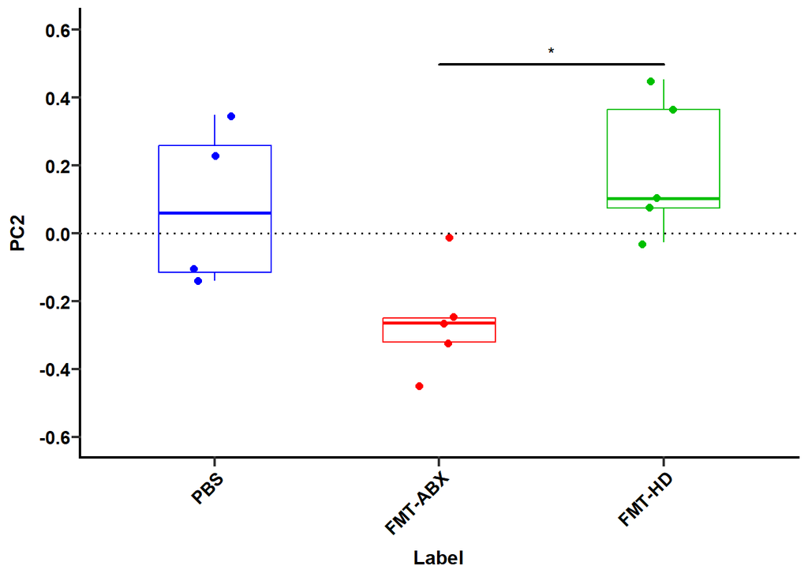

```r
Figure2B = ggplot(subj_ord, aes(x = Label, y = PC2, fill = Label, color = Label)) +
  geom_boxplot(
    fill  = "white",
    width = 0.5,
    outlier.shape = NA
  ) +
  geom_point(
    position = position_jitter(width = 0.1),
    size = 2
  ) +
  geom_hline(yintercept = 0, linetype = "dotted", linewidth = 0.6) +
  stat_compare_means(
    comparisons = list(c("FMTCTRL", "FMTABX"), c("FMTABX", "FMTPBS")),
    label = "p.signif",
    bracket.size = 0.75, tip.length = 0,
  ) +
  scale_fill_manual(
    values = c("FMTABX" = three_colors[["FMT-ABX"]], "FMTCTRL" = three_colors[["FMT-HD"]], "FMTPBS" = three_colors[["PBS"]]),
    labels = c("FMTABX" = "FMT-ABX", "FMTCTRL" = "FMT-HD", "FMTPBS" = "PBS"),
    breaks = c("FMTPBS", "FMTABX", "FMTCTRL")
  ) +
  scale_color_manual(
    values = c("FMTABX" = three_colors[["FMT-ABX"]], "FMTCTRL" = three_colors[["FMT-HD"]], "FMTPBS" = three_colors[["PBS"]]),
    labels = c("FMTABX" = "FMT-ABX", "FMTCTRL" = "FMT-HD", "FMTPBS" = "PBS"),
    breaks = c("FMTPBS", "FMTABX", "FMTCTRL")
  ) +
  scale_x_discrete(
    limits = c("FMTPBS", "FMTABX", "FMTCTRL"),
    labels = c("FMTPBS" = "PBS", "FMTABX" = "FMT-ABX", "FMTCTRL" = "FMT-HD"),
  ) +
  scale_y_continuous(
    limits = c(-0.6, 0.6),
    breaks = seq(-0.6, 0.6, by = 0.2),
    labels = scales::number_format(accuracy = 0.1)
  ) +
  labs(x = "Label", y = "PC2", fill = NULL, color = NULL) +
  theme_prism(base_size = 12, base_fontface = "bold") +
  theme(
    legend.position   = "none",
    panel.grid        = element_blank(),
    axis.text.x       = element_text(angle = 45, hjust = 1, vjust = 1)
  )
Figure2B
```

```r
ggexport(Figure2B, filename = paste0(FMT_figpath, "Figure2B.png"), width=200, height=300)
```

```
## file saved to C:/Users/ETTINA03/NYU Langone Health Dropbox/April Jauhal/Shenhav_Lab/Morrowitz_16S/2024_Jul_FMT//Figures/Figure2B.png
```

Figure 2C

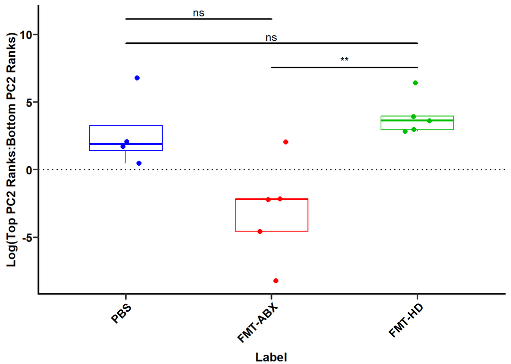

```r
Figure2C = ggplot(subj_ord, aes(x = Label, y = PC2_10perc, fill = Label, color = Label)) +
  geom_boxplot(
    fill  = "white",
    width = 0.5,
    outlier.shape = NA
  ) +
  geom_point(
    position = position_jitter(width = 0.1),
    size = 2
  ) +
  geom_hline(yintercept = 0, linetype = "dotted", linewidth = 0.6) +
  stat_compare_means(
    comparisons = list(c("FMTCTRL", "FMTABX"),
                       c("FMTCTRL", "FMTPBS"),
                       c("FMTPBS",  "FMTABX")),
    label        = "p.signif",
    bracket.size = 0.75,
    tip.length   = 0
  ) +
  scale_fill_manual(
    values = c("FMTABX" = three_colors[["FMT-ABX"]], "FMTCTRL" = three_colors[["FMT-HD"]], "FMTPBS" = three_colors[["PBS"]]),
    labels = c("FMTABX" = "FMT-ABX", "FMTCTRL" = "FMT-HD", "FMTPBS" = "PBS"),
    breaks = c("FMTPBS", "FMTABX", "FMTCTRL")
  ) +
  scale_color_manual(
    values = c("FMTABX" = three_colors[["FMT-ABX"]], "FMTCTRL" = three_colors[["FMT-HD"]], "FMTPBS" = three_colors[["PBS"]]),
    labels = c("FMTABX" = "FMT-ABX", "FMTCTRL" = "FMT-HD", "FMTPBS" = "PBS"),
    breaks = c("FMTPBS", "FMTABX", "FMTCTRL")
  ) +
  scale_x_discrete(
    limits = c("FMTPBS", "FMTABX", "FMTCTRL"),
    labels = c("FMTPBS" = "PBS", "FMTABX" = "FMT-ABX", "FMTCTRL" = "FMT-HD")
  ) +
  labs(
    x     = "Label",
    y     = "Log(Top PC2 Ranks:Bottom PC2 Ranks)",
    fill  = NULL,
    color = NULL
  ) +
  theme_prism(base_size = 12, base_fontface = "bold") +
  theme(
    legend.position = "none",
    panel.grid      = element_blank(),
    axis.text.x     = element_text(angle = 45, hjust = 1, vjust = 1)
  )
Figure2C
```

```r
ggexport(Figure2C, filename = paste0(FMT_figpath, "Figure2C.png"), width=200, height=300)
```

```
## file saved to C:/Users/ETTINA03/NYU Langone Health Dropbox/April Jauhal/Shenhav_Lab/Morrowitz_16S/2024_Jul_FMT//Figures/Figure2C.png
```

## ANCOMBC2 analysis

Main analysis (Results used to construct Figure 2D in PRISM)

```r
set.seed(123)
res_label_24_genus <- ancombc2(data = subset_samples(subset_samples(FMT_physeq_filtered_counts, Label %in% c("FMTABX", "FMTCTRL", "FMTPBS")), Timepoint ==24),
                          tax_level = "Genus",
                          fix_formula = "Label",
                          rand_formula = NULL,
                          p_adj_method = "holm", pseudo_sens = TRUE,
                          prv_cut = 0, lib_cut = 0, s0_perc = 0.05,
                          group = "Label", struc_zero = TRUE, neg_lb = FALSE,
                          alpha = 0.05, n_cl = 2, verbose = TRUE,
                          global = TRUE, pairwise = TRUE, dunnet = TRUE, trend = FALSE,
                          iter_control = list(tol = 1e-2, max_iter = 20,
                                              verbose = TRUE),
                          em_control = list(tol = 1e-5, max_iter = 100),
                          lme_control = NULL,
                          mdfdr_control = list(fwer_ctrl_method = "holm", B = 100),
                          trend_control = NULL)
```

```
## Obtaining initial estimates ...
```

```
## ML iteration = 1, epsilon = 1.7
```

```
## ML iteration = 2, epsilon = 3.3
```

```
## ML iteration = 3, epsilon = 0.7
```

```
## ML iteration = 4, epsilon = 0.17
```

```
## ML iteration = 5, epsilon = 0.047
```

```
## ML iteration = 6, epsilon = 0.015
```

```
## ML iteration = 7, epsilon = 0.005
```

```
## Estimating sample-specific biases ...
```

```
## Sensitivity analysis for pseudo-count addition to 0s: ...
```

```
## ANCOM-BC2 primary results ...
```

```
## ANCOM-BC2 global test ...
```

```
## ANCOM-BC2 multiple pairwise comparisons ...
```

```
## ANCOM-BC2 multiple pairwise comparisons against the reference group ...
```

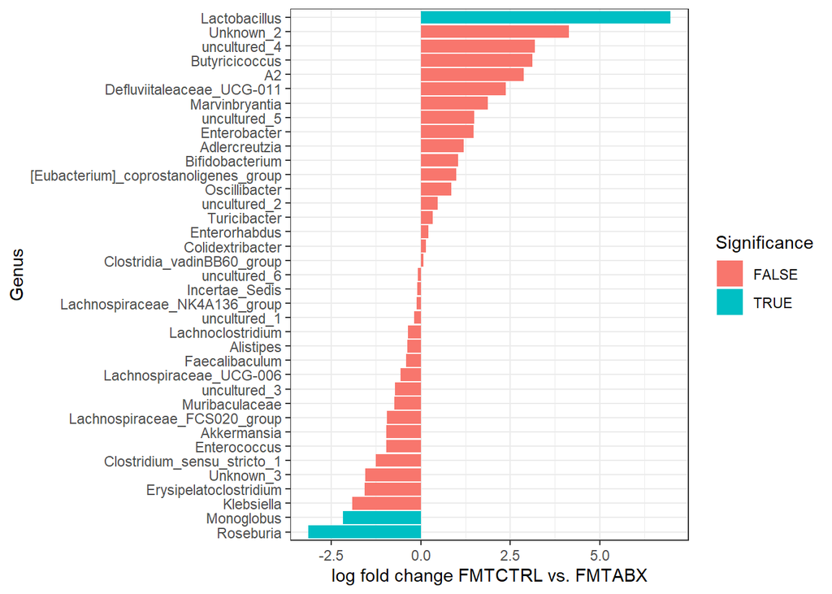

```r
res_24_genus = res_label_24_genus$res_pair

ggplot(res_24_genus %>% mutate(taxon = factor(res_24_genus$taxon, levels = (res_24_genus %>% arrange(lfc_LabelFMTCTRL) %>% pull(taxon)))),
       aes(y=taxon, x=lfc_LabelFMTCTRL, fill = diff_LabelFMTCTRL)) + geom_bar(stat="identity") + ylab("Genus") + xlab("log fold change FMTCTRL vs. FMTABX") + labs(fill="Significance")
```

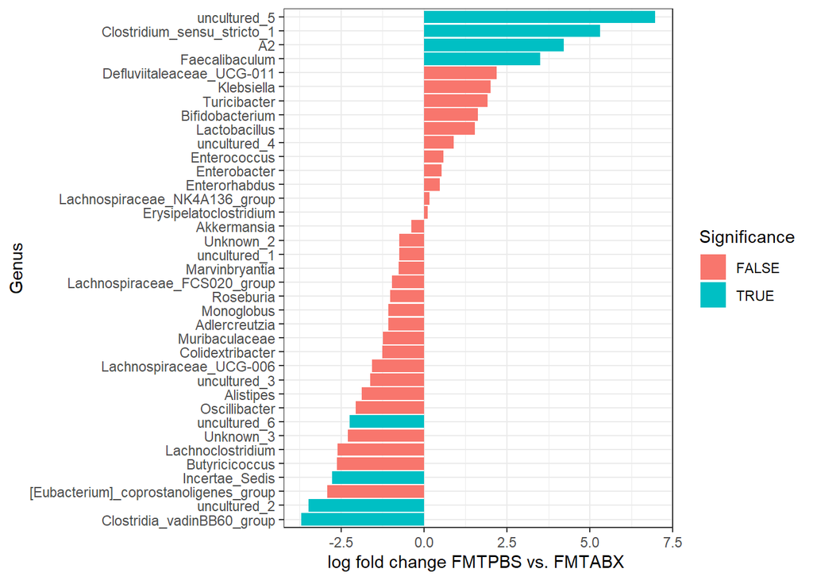

```r
ggplot(res_24_genus %>% mutate(taxon = factor(res_24_genus$taxon, levels = (res_24_genus %>% arrange(lfc_LabelFMTPBS) %>% pull(taxon)))),
       aes(y=taxon, x=lfc_LabelFMTPBS, fill = diff_LabelFMTPBS)) + geom_bar(stat="identity") + ylab("Genus") + xlab("log fold change FMTPBS vs. FMTABX ") + labs(fill="Significance")
```

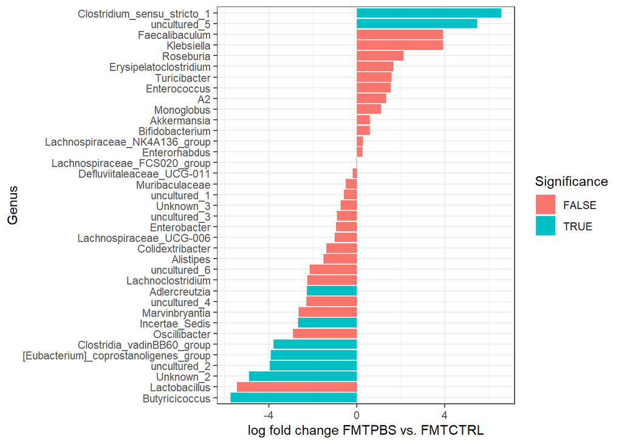

```r
ggplot(res_24_genus %>% mutate(taxon = factor(res_24_genus$taxon, levels = (res_24_genus %>% arrange(lfc_LabelFMTPBS_LabelFMTCTRL) %>% pull(taxon)))),
       aes(y=taxon, x=lfc_LabelFMTPBS_LabelFMTCTRL, fill = diff_LabelFMTPBS_LabelFMTCTRL)) + geom_bar(stat="identity") + ylab("Genus") + xlab("log fold change FMTPBS vs. FMTCTRL") + labs(fill="Significance")
```

```r
res_24_genus %>% mutate(taxon = factor(res_24_genus$taxon, levels = (res_24_genus %>% arrange(lfc_LabelFMTCTRL) %>% pull(taxon)))) %>% dplyr::select(taxon,lfc_LabelFMTCTRL, p_LabelFMTCTRL)
```

```
##                                    taxon lfc_LabelFMTCTRL p_LabelFMTCTRL
## 1                             Klebsiella      -1.91311652    1.000000000
## 2                          Lactobacillus       6.97730177    0.002701317
## 3                           Turicibacter       0.32751391    1.000000000
## 4                         Muribaculaceae      -0.72777524    1.000000000
## 5                            Akkermansia      -0.96015015    1.000000000
## 6                        Bifidobacterium       1.03973228    0.117642715
## 7                           Enterobacter       1.47024420    1.000000000
## 8                Lachnospiraceae_UCG-006      -0.55613034    1.000000000
## 9                              Roseburia      -3.14165558    0.002038026
## 10                          Enterococcus      -0.96775871    1.000000000
## 11                        Faecalibaculum      -0.41472264    0.747920967
## 12                     Lachnoclostridium      -0.35521542    1.000000000
## 13                             Alistipes      -0.36990352    1.000000000
## 14         Lachnospiraceae_NK4A136_group      -0.11859232    1.000000000
```

[output cut: 23 more lines]

```r
res_24_genus %>% mutate(taxon = factor(res_24_genus$taxon, levels = (res_24_genus %>% arrange(lfc_LabelFMTCTRL) %>% pull(taxon)))) %>% dplyr::select(taxon,lfc_LabelFMTCTRL, p_LabelFMTCTRL, q_LabelFMTCTRL) %>% filter(p_LabelFMTCTRL < 0.05)
```

```
##                       taxon lfc_LabelFMTCTRL p_LabelFMTCTRL q_LabelFMTCTRL
## 1             Lactobacillus         6.977302    0.002701317     0.01665812
## 2                 Roseburia        -3.141656    0.002038026     0.01256783
## 3                        A2         2.879097    0.010197069     0.05268485
## 4                 Unknown_2         4.147277    0.017023490     0.08795470
## 5                Monoglobus        -2.176317    0.007956081     0.04906250
## 6 Defluviitaleaceae_UCG-011         2.383425    0.039301036     0.20305535
## 7            Butyricicoccus         3.112596    0.014101534     0.07285792
```

```r
res_24_genus %>%
  mutate(fold_change = exp(lfc_LabelFMTCTRL), log_fold_change = log(fold_change, base = exp(1))) %>%
  dplyr::select(taxon, fold_change, log_fold_change) %>%
  write.csv(paste0(FMT_dir, "fold_change_values.csv"))
```

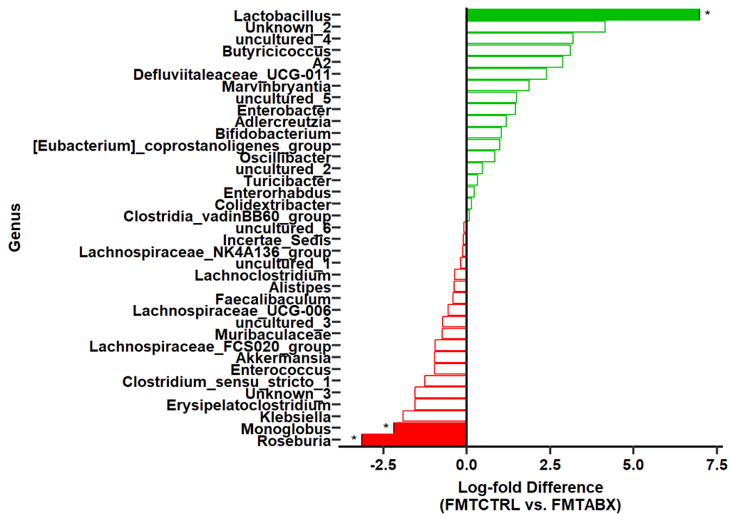

```r
# Prepare data with significance stars
res_24_genus_plot_df = res_24_genus %>%
  mutate(
    taxon = factor(taxon, levels = (res_24_genus %>%
                     arrange(lfc_LabelFMTCTRL) %>%
                     pull(taxon))),
    # Direction for color (negative = red, positive = green)
    direction = ifelse(lfc_LabelFMTCTRL < 0, "neg", "pos"),
    # Significance determines fill vs outline
    sig = diff_LabelFMTCTRL,
    # Star labels for significant taxa
    stars = case_when(
      q_LabelFMTCTRL < 0.001 ~ "***",
      q_LabelFMTCTRL < 0.01  ~ "**",
      q_LabelFMTCTRL < 0.05  ~ "*",
      TRUE ~ ""
    )
  ) %>%
  arrange(desc(lfc_LabelFMTCTRL))

Figure2C = ggplot(res_24_genus_plot_df, aes(y = taxon, x = lfc_LabelFMTCTRL)) +
  # Outlined (non-significant) bars
  geom_bar(data = filter(res_24_genus_plot_df, !sig),
           stat = "identity",
           fill = "white",
           color = NA,
           alpha = 0.15) +
  # Filled (significant) bars
  geom_bar(data = filter(res_24_genus_plot_df, sig),
           stat = "identity",
           aes(fill = direction),
           color = NA,
           alpha = 1) +
  # Outline for all bars
  geom_bar(stat = "identity",
           aes(color = direction),
           fill = NA,
           linewidth = 0.4) +
  # Vertical line at 0
  geom_vline(xintercept = 0, linewidth = 0.8, color = "black") +
  scale_y_discrete(limits = levels(res_24_genus_plot_df$taxon)) +
  # Significance stars — placed just beyond bar end
  geom_text(aes(
    x = lfc_LabelFMTCTRL + ifelse(lfc_LabelFMTCTRL >= 0, 0.15, -0.15),
    label = stars,
    hjust = ifelse(lfc_LabelFMTCTRL >= 0, 0, 1)
  ), size = 3.5) +
  # Tick marks at bar ends for significant taxa (mimics prism style)
  geom_segment(data = filter(res_24_genus_plot_df, sig),
               aes(x = lfc_LabelFMTCTRL,
                   xend = lfc_LabelFMTCTRL,
                   y = as.numeric(taxon) - 0.45,
                   yend = as.numeric(taxon) + 0.45),
               color = "black", linewidth = 0.5) +
  # Colors: red for negative, green for positive
  scale_fill_manual(values  = c("neg" = three_colors[["FMT-ABX"]], "pos" = three_colors[["FMT-HD"]])) +
  scale_color_manual(values = c("neg" = three_colors[["FMT-ABX"]], "pos" = three_colors[["FMT-HD"]])) +
  # Prism theme
  theme_prism(base_size = 11, base_fontface = "bold") +
  theme(
    legend.position = "none",
    axis.line.y     = element_blank(),   # remove y-axis line (prism style)
    panel.grid      = element_blank()
  ) +
  labs(
    y = "Genus",
    x = "Log-fold Difference\n(FMTCTRL vs. FMTABX)"
  )
Figure2C
```

```r
ggexport(Figure2C, filename = paste0(FMT_figpath, "Figure2D.png"), width = 500, height = 500)
```

```
## file saved to C:/Users/ETTINA03/NYU Langone Health Dropbox/April Jauhal/Shenhav_Lab/Morrowitz_16S/2024_Jul_FMT//Figures/Figure2D.png
```

```r
genus_meta_df = otu_table(FMT_genus) %>% t() %>% data.frame() %>% tibble::rownames_to_column("Sample") %>%
  left_join(meta)
```

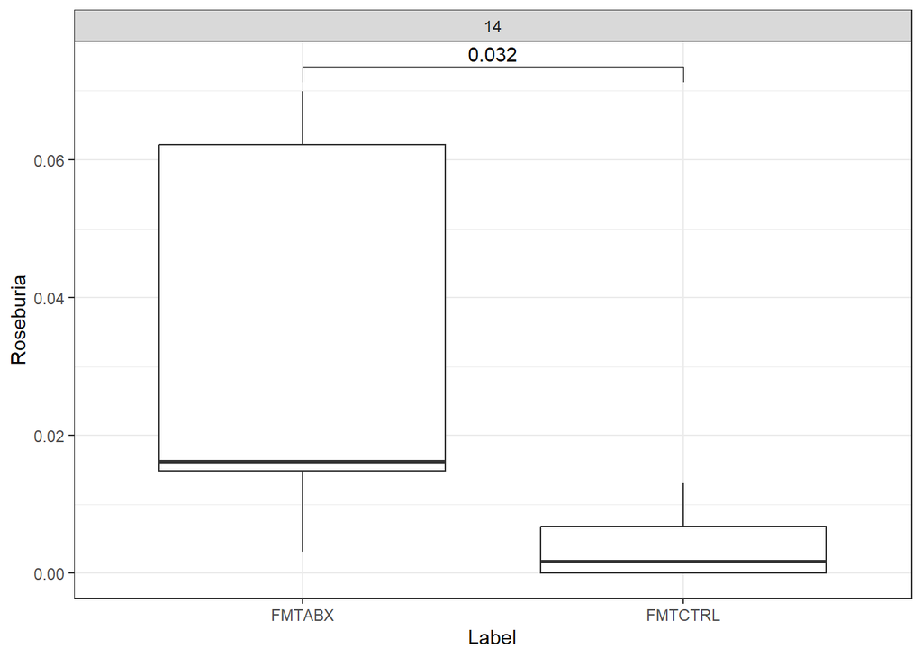

```r
Roseburia = FMT_physeq_filtered_counts %>% tax_table ()%>% as.data.frame() %>% filter(Genus=="Roseburia") %>% rownames()

ggplot(genus_meta_df %>% filter(Timepoint==14, Label %in% c("FMTABX", "FMTCTRL")), aes(x=Label, y=!!sym(Roseburia))) + geom_boxplot() + facet_grid(.~Timepoint) +
  stat_compare_means(comparisons = list(c("FMTABX", "FMTCTRL"))) + ylab("Roseburia")
```